# Heat and health: logistic and Poisson regression

GEOG 531 · A companion to the OLS, categorical-predictor and interaction lab

Author

Varun Goel

## The same setting, different outcomes

We return to the same 736 artificial tracts in 46 fictional county groups in hypothetical 2025. The geography and values are simulated, not estimates for South Carolina. This file generates all its own data and can be uploaded to Posit Cloud by itself. It does not read another lab or a CSV.

This time we model:

| Outcome | Measurement | Model |
| --- | --- | --- |
| `resident_heat_illness` | One sampled resident per tract reports illness, 1 = yes and 0 = no, during the same complete hypothetical year | Logistic |
| `heat_visits` | Annual tract count of heat-related emergency episodes, including repeats | Poisson with an exposure offset |
| `heat_visits_extra` | A separate annual count outcome deliberately generated with extra conditional variation | Poisson screen, then quasi-Poisson / negative binomial |

The binary outcome is **one observation**, not a tract proportion observed without error. The annual count concerns the tract population.

## 0 · setup

```r
needed <- c("tidyverse", "broom", "MASS", "knitr", "rmarkdown")
missing <- needed[!vapply(needed, requireNamespace, logical(1), quietly = TRUE)]
if (length(missing) > 0) stop("Install these packages first: ", paste(missing, collapse = ", "))
if (getRversion() < "4.1.0") stop("Use R 4.1 or newer.")

library(tidyverse)
library(broom)
theme_set(theme_minimal(base_size = 12))
options(dplyr.summarise.inform = FALSE,
        contrasts = c("contr.treatment", "contr.poly"))
```

We use `MASS::glm.nb()` later, without attaching MASS. This keeps the familiar `dplyr::select()` available without a package-name conflict.

### Supplied simulation

You do not need to type or derive this folded code. It recreates the original tract covariates, corrects the deliberately bad continuous-outcome record from its verified source, assigns the new baseline categories, and generates the GLM outcomes. The original continuous health outcome is not used as a GLM predictor.

**Supplied self-contained data generator**

```r
simulate_sc <- function(seed = 5312025) {
  # Park–Miller uniforms, with exactly representable integer arithmetic.
  state <- as.double(seed)
  stopifnot(state > 0, state < 2147483647, state == floor(state))
  next_u <- function(n) {
    out <- numeric(n)
    for (j in seq_len(n)) {
      state <<- (16807 * state) %% 2147483647
      out[j] <- state / 2147483647
    }
    out
  }
  next_z <- function(n) qnorm(next_u(n))
  clamp <- function(x, lower, upper) pmin(upper, pmax(lower, x))

  # 46 artificial county blocks, each containing 16 artificial tracts.
  counties <- expand_grid(county_y = 1:6, county_x = 1:8) |>
    filter(!(county_y == 6 & county_x %in% c(1, 8))) |>
    mutate(county_number = row_number(),
           county_id = str_c("SCsim_", str_pad(county_number, 2, pad = "0")),
           hidden_context = next_z(n()))

  grid <- crossing(county_number = 1:46, local_y = 0:3, local_x = 0:3) |>
    left_join(counties, by = "county_number") |>
    arrange(county_number, local_y, local_x) |>
    mutate(x = (county_x - 1) * 4 + local_x + 1,
           y = (county_y - 1) * 4 + local_y + 1)

  n <- nrow(grid)
  east <- (grid$x - mean(grid$x)) / sd(grid$x)
  context <- grid$hidden_context
  poverty <- clamp(18 + 2 * context + 7 * next_z(n) + 3 * east, 4, 40)
  impervious <- clamp(40 + 4 * context + 14 * next_z(n) + 8 * east, 5, 90)
  imp <- (impervious - 40) / 10
  heat_rate <- exp(2.1 + .018 * poverty + .13 * imp + .28 * context + .12 * east)
  heat <- as.integer(qpois(next_u(n), lambda = heat_rate))
  hardship <- 2 * poverty + .4 * next_z(n)

  # Rook adjacency: share a side on the artificial grid.
  A <- 1 * ((abs(outer(grid$x, grid$x, "-")) +
               abs(outer(grid$y, grid$y, "-"))) == 1)
  stopifnot(all(rowSums(A) > 0))
  W <- A / rowSums(A)
  rho <- .70
  spatial_filter <- diag(n) - rho * W
  sigma <- .25 + .035 * heat + .015 * poverty
  z_m <- next_z(n)
  z_y <- next_z(n)
  components <- solve(spatial_filter, cbind(.35 * z_m, sigma * z_y))
  disruption <- .20 * heat + .02 * poverty + .15 * imp + components[, 1]

  # Total heat effect: .10 directly + (.20 * .40) through disruption = .18.
  mu_total <- 3 + .18 * heat + .048 * poverty + .31 * imp +
    .20 * imp^2 + .65 * context
  health <- 3 + .10 * heat + .40 * disruption + .04 * poverty +
    .25 * imp + .20 * imp^2 + .65 * context + components[, 2]

  dat <- tibble(
    tract_id = str_c("T", str_pad(seq_len(n), 4, pad = "0")),
    county_id = factor(grid$county_id), year = 2025L,
    x = grid$x, y = grid$y, heat_days = heat,
    poor_health_days = health, poverty_pct = poverty,
    hardship_index = hardship, impervious_pct = impervious,
    impervious_c10 = imp, disruption_index = disruption
  )
  audit <- tibble(
    tract_id = dat$tract_id[371],
    verified_poor_health_days = dat$poor_health_days[371],
    audit_note = "Source entry check: added 35 days during data entry."
  )
  dat$poor_health_days[371] <- dat$poor_health_days[371] + 35
  dimnames(W) <- list(dat$tract_id, dat$tract_id)

  list(data = dat, audit = audit, W = W,
       truth = list(total_effect = .18, direct_effect = .10,
                    indirect_effect = .08, rho = rho, mu_total = mu_total,
                    hidden_context = context, innovation_sd = sigma))
}


add_modifier_data <- function(data, seed = 531917) {
  state <- as.double(seed)
  next_u <- function(n) {
    out <- numeric(n)
    for (j in seq_len(n)) {
      state <<- (16807 * state) %% 2147483647
      out[j] <- state / 2147483647
    }
    out
  }
  n <- nrow(data)
  u <- next_u(n)
  cooling <- case_when(u < .40 ~ "Limited", u < .75 ~ "Partial", TRUE ~ "Reliable")
  housing <- if_else(next_u(n) < plogis(-.5 + .035 * (data$poverty_pct - 20)),
                     "Vulnerable", "Standard")
  program <- if_else(next_u(n) < .50, "Yes", "No")
  h <- (data$heat_days - 15) / 5
  p <- (data$poverty_pct - 20) / 10
  part <- as.numeric(cooling == "Partial")
  reliable <- as.numeric(cooling == "Reliable")
  vulnerable <- as.numeric(housing == "Vulnerable")
  yes <- as.numeric(program == "Yes")

  modifier_contribution <- -.40 * part - .80 * reliable + .45 * vulnerable -
    .25 * yes + .25 * h * p - .20 * h * part - .45 * h * reliable -
    .65 * yes * vulnerable

  data |>
    mutate(heat5 = h, poverty10 = p,
           impervious_c10_sq = impervious_c10^2,
           cooling_access = factor(cooling, levels = c("Limited", "Partial", "Reliable")),
           housing_profile = factor(housing, levels = c("Standard", "Vulnerable")),
           warning_program = factor(program, levels = c("No", "Yes")),
           poor_health_days_modified = poor_health_days + modifier_contribution)
}

add_glm_outcomes <- function(data, seed = 5311125) {
  state <- as.double(seed)
  next_u <- function(n) {
    out <- numeric(n)
    for (j in seq_len(n)) {
      state <<- (16807 * state) %% 2147483647
      out[j] <- state / 2147483647
    }
    out
  }
  n <- nrow(data)
  h <- data$heat5
  p <- data$poverty10
  i <- data$impervious_c10
  part <- as.numeric(data$cooling_access == "Partial")
  reliable <- as.numeric(data$cooling_access == "Reliable")
  vulnerable <- as.numeric(data$housing_profile == "Vulnerable")
  yes <- as.numeric(data$warning_program == "Yes")

  eta <- -1.25 + .40 * h + .35 * p + .18 * i + .10 * i^2 -
    .35 * part - .75 * reliable + .40 * vulnerable - .25 * yes -
    .10 * h * part - .22 * h * reliable
  probability <- plogis(eta)
  illness <- as.integer(qbinom(next_u(n), size = 1, prob = probability))
  population <- as.integer(floor(600 + 3400 * next_u(n)))
  log_rate <- -6 + .28 * h + .30 * p + .15 * i + .08 * i^2 -
    .20 * part - .45 * reliable + .35 * vulnerable - .25 * yes -
    .08 * h * part - .16 * h * reliable
  mu <- population * exp(log_rate)
  visits <- as.integer(qpois(next_u(n), lambda = mu))
  theta <- 1.5
  visits_extra <- as.integer(qnbinom(next_u(n), size = theta, mu = mu))

  list(data = data |>
         mutate(resident_heat_illness = illness, population_2025 = population,
                person_years = population, heat_visits = visits,
                heat_visits_extra = visits_extra),
       truth = list(probability = probability, expected_visits = mu,
                    nb_theta = theta, outcomes_conditionally_independent = TRUE))
}

sim <- simulate_sc()
base_data <- sim$data |>
  left_join(sim$audit, by = "tract_id") |>
  mutate(poor_health_days = coalesce(verified_poor_health_days, poor_health_days)) |>
  select(-verified_poor_health_days, -audit_note) |>
  add_modifier_data()

glm_sim <- add_glm_outcomes(base_data)
gdat <- glm_sim$data
glm_truth <- glm_sim$truth
```

### Predictor definitions

| Predictor | Reference / unit |
| --- | --- |
| `heat5` | `(heat_days - 15) / 5`: one unit = five additional heat days |
| `poverty10` | `(poverty_pct - 20) / 10`: one unit = ten percentage points |
| `impervious_c10` | `(impervious_pct - 40) / 10` |
| `impervious_c10_sq` | Squared centered impervious term for mean-model shape |
| `cooling_access` | Limited, Partial, Reliable; Limited is the reference |
| `housing_profile` | Standard or Vulnerable; Standard is the reference |
| `warning_program` | No or Yes; No is the reference |
| `person_years` | Tract population observed for the full year; positive exposure for the count model |

The full-year follow-up is the same for all count observations. Exposure varies because populations differ, so person-years equal population here. The resident’s illness outcome uses the same complete year, but supplies one binary response rather than a population episode count. It has no person-year offset.

## 1 · Choose the outcome-specific DAG and model

Poverty and impervious cover are pre-exposure causes of both heat and these GLM outcomes. Poverty also influences the housing profile. Cooling access, housing profile and the exogenous pre-season program predict the outcome; cooling modifies the heat comparison in the specified GLMs.

```
flowchart TD
  C["County context"] --> P["Poverty"]
  C --> I["Impervious cover"]
  C --> H["Heat days"]
  P --> H
  I --> H
  P --> Y["GLM outcome"]
  I --> Y
  P --> V["Housing profile"]
  V --> Y
  H --> Y
  A["Cooling access"] --> Y
  G["Warning program"] --> Y
```

```
flowchart TD
  C["County context"] --> P["Poverty"]
  C --> I["Impervious cover"]
  C --> H["Heat days"]
  P --> H
  I --> H
  P --> Y["GLM outcome"]
  I --> Y
  P --> V["Housing profile"]
  V --> Y
  H --> Y
  A["Cooling access"] --> Y
  G["Warning program"] --> Y
```

**Unlike the continuous-outcome generator**, there is no remaining direct county-context contribution to these outcome means after the specified predictors. Thus the measured poverty/impervious adjustment blocks the designated heat backdoor paths here, and county fixed effects are not required by this outcome-specific generator. The original service-disruption mediator is not part of these simplified GLM-generating equations. Do not transfer a DAG or a spatial error assumption across outcomes without checking the question. What this means is that if you had an OLS model, and suddenly you decide that a Logit or Poisson is better, you cannot simply ‘move over’ your DAG to the questions.

## 2 · Logistic regression: binary outcome, odds and probability

```r
gdat |> count(resident_heat_illness) |> mutate(proportion = n / sum(n))
```

```
# A tibble: 2 × 3
  resident_heat_illness     n proportion
                  <int> <int>      <dbl>
1                     0   584      0.793
2                     1   152      0.207
```

```r
gdat |>
  group_by(cooling_access, housing_profile) |>
  summarise(n = n(), events = sum(resident_heat_illness),
            non_events = sum(resident_heat_illness == 0), .groups = "drop")
```

```
# A tibble: 6 × 5
  cooling_access housing_profile     n events non_events
  <fct>          <fct>           <int>  <int>      <int>
1 Limited        Standard          179     38        141
2 Limited        Vulnerable        102     34         68
3 Partial        Standard          167     28        139
4 Partial        Vulnerable        115     25         90
5 Reliable       Standard          109     14         95
6 Reliable       Vulnerable         64     13         51
```

Confirm that 1 means the event you want to model. Sparse predictor/outcome cells can produce instability or separation. A model might return enormous coefficients or convergence warnings even though its formula is syntactically correct.

### First fit a working additive model

```r
logit_add <- glm(
  resident_heat_illness ~ heat5 + poverty10 + impervious_c10 + impervious_c10_sq +
    cooling_access + housing_profile + warning_program,
  family = binomial(link = "logit"), data = gdat
)

tidy(logit_add, conf.int = TRUE, exponentiate = TRUE) |>
  select(term, estimate, conf.low, conf.high)
```

```
# A tibble: 9 × 4
  term                      estimate conf.low conf.high
  <chr>                        <dbl>    <dbl>     <dbl>
1 (Intercept)                  0.276    0.181     0.414
2 heat5                        1.43     1.21      1.70
3 poverty10                    1.42     1.05      1.91
4 impervious_c10               1.21     1.05      1.40
5 impervious_c10_sq            1.07     1.01      1.14
6 cooling_accessPartial        0.567    0.362     0.881
7 cooling_accessReliable       0.453    0.259     0.773
8 housing_profileVulnerable    1.36     0.911     2.03
9 warning_programYes           0.898    0.603     1.33
```

Exponentiated **slopes** are odds ratios. An OR of 1 is the null comparison. An OR below 1 describes lower odds, not necessarily the same percentage reduction in probability. The exponentiated intercept is baseline odds, not a slope contrast.

This additive model assumes a constant heat OR across cooling categories. Our modified question asks whether that assumption is adequate.

### Add the prespecified heat-by-cooling interaction

```r
logit_model <- glm(
  resident_heat_illness ~ heat5 * cooling_access + poverty10 +
    impervious_c10 + impervious_c10_sq + housing_profile + warning_program,
  family = binomial(link = "logit"), data = gdat
)

tidy(logit_model, conf.int = TRUE, exponentiate = TRUE) |>
  select(term, estimate, conf.low, conf.high)
```

```
# A tibble: 11 × 4
   term                         estimate conf.low conf.high
   <chr>                           <dbl>    <dbl>     <dbl>
 1 (Intercept)                     0.269    0.176     0.406
 2 heat5                           1.57     1.23      2.03
 3 cooling_accessPartial           0.584    0.370     0.913
 4 cooling_accessReliable          0.467    0.265     0.799
 5 poverty10                       1.41     1.05      1.90
 6 impervious_c10                  1.20     1.04      1.39
 7 impervious_c10_sq               1.08     1.02      1.14
 8 housing_profileVulnerable       1.36     0.909     2.02
 9 warning_programYes              0.903    0.606     1.34
10 heat5:cooling_accessPartial     0.862    0.634     1.17
11 heat5:cooling_accessReliable    0.862    0.608     1.23
```

The heat OR now applies to the Limited-cooling group. To obtain another cooling group’s heat OR, add its interaction coefficient on the **log-odds scale**, then exponentiate; equivalently multiply the corresponding exponentiated terms. Exponentiated interaction coefficients are **ratios of odds ratios**. Their confidence intervals are not automatically intervals for either group’s complete heat OR.

## 3 · Use predicted probabilities and meaningful contrasts

The helper creates fixed illustrative profiles with 20% poverty, 40% impervious cover, Standard housing and no program, unless overridden. It uses all valid factor levels from the generated data.

```r
make_glm_profiles <- function(heat_days = 15, cooling_access = "Limited",
                              poverty_pct = 20, housing_profile = "Standard",
                              warning_program = "No", person_years = 1000) {
  crossing(heat_days = heat_days, cooling_access = cooling_access,
           poverty_pct = poverty_pct, housing_profile = housing_profile,
           warning_program = warning_program, person_years = person_years) |>
    mutate(heat5 = (heat_days - 15) / 5, poverty10 = (poverty_pct - 20) / 10,
           impervious_c10 = 0, impervious_c10_sq = 0,
           cooling_access = factor(cooling_access, levels = levels(gdat$cooling_access)),
           housing_profile = factor(housing_profile, levels = levels(gdat$housing_profile)),
           warning_program = factor(warning_program, levels = levels(gdat$warning_program)))
}
```

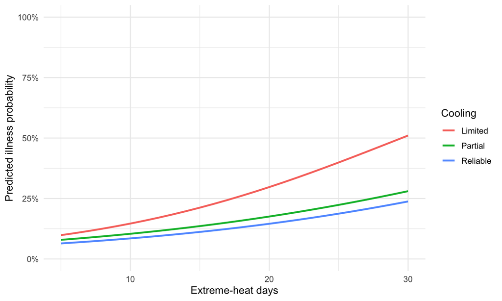

```r
probability_grid <- make_glm_profiles(heat_days = 5:30,
                                      cooling_access = levels(gdat$cooling_access))

probability_predictions <- augment(logit_model, newdata = probability_grid,
                                    type.predict = "response")

probability_predictions |>
  ggplot(aes(heat_days, .fitted, color = cooling_access)) +
  geom_line(linewidth = 1) +
  scale_y_continuous(labels = scales::label_percent(), limits = c(0, 1)) +
  labs(x = "Extreme-heat days", y = "Predicted illness probability", color = "Cooling")
```

```r
augment(logit_model,
        newdata = make_glm_profiles(heat_days = c(10, 15),
                                    cooling_access = levels(gdat$cooling_access)),
        type.predict = "response") |>
  select(cooling_access, heat_days, .fitted) |>
  pivot_wider(names_from = heat_days, values_from = .fitted, names_prefix = "heat_") |>
  mutate(probability_difference_pp = 100 * (heat_15 - heat_10))
```

```
# A tibble: 3 × 4
  cooling_access heat_10 heat_15 probability_difference_pp
  <fct>            <dbl>   <dbl>                     <dbl>
1 Limited         0.146    0.212                      6.58
2 Partial         0.104    0.136                      3.18
3 Reliable        0.0850   0.112                      2.67
```

The same fitted model can give each group’s five-day OR by comparing **log-odds predictions** and exponentiating their difference. This includes the main and interaction terms together.

```r
augment(logit_model,
        newdata = make_glm_profiles(heat_days = c(10, 15),
                                    cooling_access = levels(gdat$cooling_access)),
        type.predict = "link") |>
  select(cooling_access, heat_days, .fitted) |>
  pivot_wider(names_from = heat_days, values_from = .fitted, names_prefix = "heat_") |>
  transmute(cooling_access, OR_per_5_heat_days = exp(heat_15 - heat_10))
```

```
# A tibble: 3 × 2
  cooling_access OR_per_5_heat_days
  <fct>                       <dbl>
1 Limited                      1.57
2 Partial                      1.35
3 Reliable                     1.35
```

## 4 · Logistic diagnostics: what can we check?

### Convergence and stability

```r
tibble(converged = purrr::pluck(logit_model, "converged"))
```

```
# A tibble: 1 × 1
  <lgl>
1 TRUE
```

```r
tidy(logit_model) |>
  arrange(desc(std.error)) |>
  select(term, estimate, std.error) |>
  slice_head(n = 5)
```

```
# A tibble: 5 × 3
  term                      estimate std.error
  <chr>                        <dbl>     <dbl>
1 cooling_accessReliable      -0.761     0.280
2 cooling_accessPartial       -0.538     0.230
3 (Intercept)                 -1.31      0.214
4 housing_profileVulnerable    0.306     0.204
5 warning_programYes          -0.103     0.203
```

Convergence does not prove no separation or a correct model. Inspect warnings, very large coefficients/SEs, sparse cells and the design. Do not report a huge OR uncritically or automatically delete rare categories to obtain a desired result.

### Mean form and influential observations

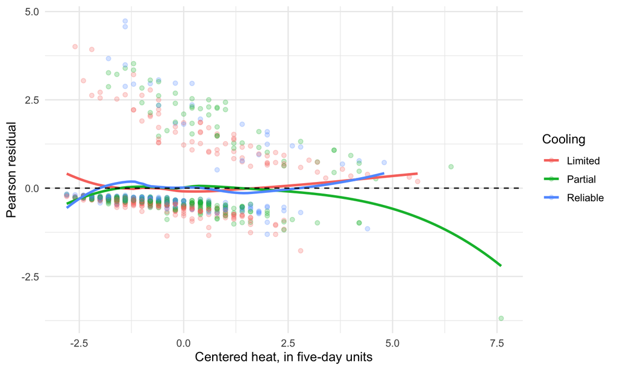

```r
logit_diagnostics <- augment(logit_model, data = gdat,
                             type.predict = "response", type.residuals = "pearson")

logit_diagnostics |>
  ggplot(aes(heat5, .resid, color = cooling_access)) +
  geom_point(alpha = .25) +
  geom_smooth(method = "loess", se = FALSE) +
  geom_hline(yintercept = 0, linetype = "dashed") +
  labs(x = "Centered heat, in five-day units", y = "Pearson residual", color = "Cooling")
```

```r
logit_diagnostics |>
  select(tract_id, cooling_access, resident_heat_illness, .fitted, .hat, .cooksd) |>
  slice_max(.cooksd, n = 5, with_ties = FALSE)
```

```
# A tibble: 5 × 6
  tract_id cooling_access resident_heat_illness .fitted    .hat .cooksd
  <chr>    <fct>                          <int>   <dbl>   <dbl>   <dbl>
1 T0468    Partial                            0  0.931  0.0423   0.0570
2 T0453    Reliable                           1  0.0963 0.0231   0.0206
3 T0669    Reliable                           1  0.0759 0.0136   0.0154
4 T0155    Limited                            1  0.120  0.0220   0.0154
5 T0568    Reliable                           1  0.0428 0.00714  0.0147
```

In OLS, a linear predictor has a straight-line relationship with the expected outcome. In logistic regression, it has a straight-line relationship with log-odds, so a curved probability relationship is normal. Look for unexplained patterns in residual plots, rather than expecting the probability curve to be straight.

In this case, the residual plot looks broadly reasonable across the main data range. There may be overprediction at high heat for the Partial-cooling group, but observations are sparse there, so we need to investigate before concluding that the model’s functional form is incorrect.”

### Checking whether complexity improves model

```r
bind_rows(glance(logit_add) |> mutate(model = "Additive"),
          glance(logit_model) |> mutate(model = "Heat × cooling")) |>
  select(model, nobs, AIC, deviance)
```

```
# A tibble: 2 × 4
  model           nobs   AIC deviance
  <chr>          <int> <dbl>    <dbl>
1 Additive         736  649.     631.
2 Heat × cooling   736  652.     630.
```

This code compares an additive logistic regression with a model that allows the heat–illness relationship to differ by cooling access through an interaction. Both models use the same outcome and the same 736 observations. **Deviance measures lack of fit: lower values indicate better fit to the observed data. AIC balances fit against model complexity: lower values are preferred.** Here, adding the interaction slightly reduces deviance, but the improvement is too small to justify the additional parameters under AIC. The additive model therefore has the lower AIC (649.30 versus 652.16). This does **not** prove that interactions are absent, that the additive model fits well in every respect, or that either model estimates causal effects. AIC provides a relative comparison of these models; residual diagnostics, causal reasoning, and evaluation on new data answer different questions.

## 5 · Poisson regression: counts need an exposure denominator

```r
gdat |>
  summarise(tracts = n(), total_visits = sum(heat_visits),
            zero_count_tracts = sum(heat_visits == 0),
            minimum_person_years = min(person_years), maximum_person_years = max(person_years),
            valid_counts = all(heat_visits >= 0 & heat_visits %% 1 == 0),
            positive_exposure = all(person_years > 0))
```

```
# A tibble: 1 × 7
  tracts total_visits zero_count_tracts minimum_person_years
   <int>        <int>             <int>                <int>
1    736         6002                44                  606
# ℹ 3 more variables: maximum_person_years <int>, valid_counts <lgl>,
#   positive_exposure <lgl>
```

Four visits in 1,000 person-years and four in 4,000 person-years have different rates. Zero is a valid count. Expected counts can be fractional even though observed counts are integers. Repeated episodes are allowed; we are not modeling a number of distinct people who ever became ill.

```r
poisson_model <- glm(
  heat_visits ~ heat5 * cooling_access + poverty10 +
    impervious_c10 + impervious_c10_sq + housing_profile + warning_program +
    offset(log(person_years)),
  family = poisson(link = "log"), data = gdat
)

tidy(poisson_model, conf.int = TRUE, exponentiate = TRUE) |>
  select(term, estimate, conf.low, conf.high)
```

```
# A tibble: 11 × 4
   term                         estimate conf.low conf.high
   <chr>                           <dbl>    <dbl>     <dbl>
 1 (Intercept)                   0.00260  0.00245   0.00276
 2 heat5                         1.33     1.30      1.35
 3 cooling_accessPartial         0.786    0.735     0.839
 4 cooling_accessReliable        0.587    0.539     0.639
 5 poverty10                     1.29     1.24      1.34
 6 impervious_c10                1.15     1.13      1.17
 7 impervious_c10_sq             1.08     1.07      1.09
 8 housing_profileVulnerable     1.43     1.36      1.51
 9 warning_programYes            0.758    0.718     0.800
10 heat5:cooling_accessPartial   0.935    0.913     0.956
11 heat5:cooling_accessReliable  0.869    0.835     0.905
```

We model the **number of heat-related emergency visits**, using an **offset for person-years** to account for differences in population size and observation time. For example, 1,000 people observed for one year contribute 1,000 person-years. The offset assumes that doubling person-years doubles the expected number of visits when other characteristics stay the same. Its coefficient is fixed at 1 rather than estimated like an ordinary predictor. The exponentiated coefficients are **incidence rate ratios (IRRs)**: values above 1 indicate higher visit rates, values below 1 indicate lower rates, and 1 indicates no difference.

Holding other variables constant, the heat IRR of **1.326** means that five additional heat days are associated with a **32.6% higher visit rate in the Limited-cooling group**. At **15 heat days**, Partial and Reliable cooling are associated with **21.4% and 41.3% lower rates**, respectively, than Limited cooling. These comparisons depend on heat exposure because the model includes an interaction. For Partial cooling, the heat IRR is **1.326 × 0.935 ≈ 1.239**, or a **23.9% higher rate per five additional heat days**. The interaction multiplies the heat IRR; it is not a percentage-point difference. These results describe relative visit rates—not additional numbers of visits, individual illness probabilities, or automatically causal effects.

## 6 · Predict counts and report rates

```r
count_profiles <- make_glm_profiles(
  heat_days = c(10, 20), cooling_access = levels(gdat$cooling_access),
  person_years = c(1000, 2000)
)

augment(poisson_model, newdata = count_profiles, type.predict = "response") |>
  transmute(heat_days, cooling_access, person_years, expected_visits = .fitted,
            rate_per_1000_person_years = 1000 * .fitted / person_years)
```

```
# A tibble: 12 × 5
   heat_days cooling_access person_years expected_visits rate_per_1000_person_…¹
       <dbl> <fct>                 <dbl>           <dbl>                   <dbl>
 1        10 Limited                1000            1.96                    1.96
 2        10 Limited                2000            3.92                    1.96
 3        10 Partial                1000            1.65                    1.65
 4        10 Partial                2000            3.30                    1.65
 5        10 Reliable               1000            1.32                    1.32
 6        10 Reliable               2000            2.65                    1.32
 7        20 Limited                1000            3.45                    3.45
 8        20 Limited                2000            6.90                    3.45
 9        20 Partial                1000            2.53                    2.53
10        20 Partial                2000            5.07                    2.53
11        20 Reliable               1000            1.76                    1.76
12        20 Reliable               2000            3.52                    1.76
# ℹ abbreviated name: ¹rate_per_1000_person_years
```

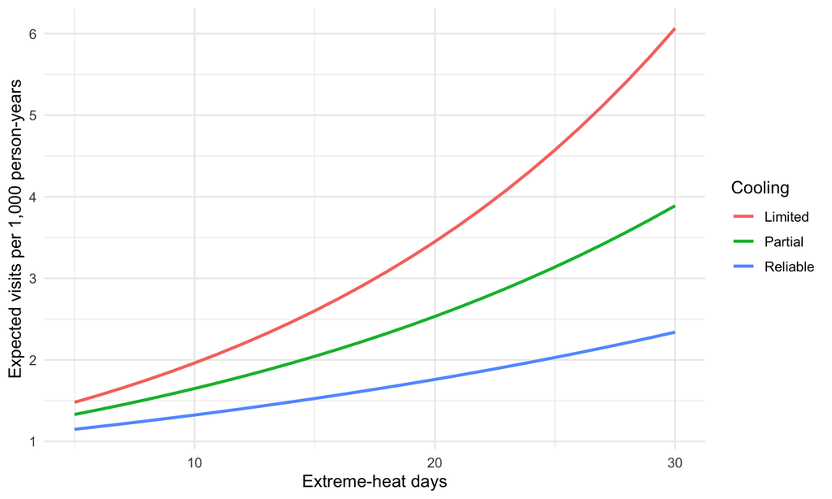

```r
augment(poisson_model,
        newdata = make_glm_profiles(heat_days = 5:30,
                                    cooling_access = levels(gdat$cooling_access),
                                    person_years = 1000),
        type.predict = "response") |>
  ggplot(aes(heat_days, .fitted, color = cooling_access)) +
  geom_line(linewidth = 1) +
  labs(x = "Extreme-heat days", y = "Expected visits per 1,000 person-years", color = "Cooling")
```

At the same exposure, differences in the model’s log expected count give rate ratios after exponentiation. Here the contrast is five heat days; the earlier 10-versus-20-day prediction table spans two such units.

```r
augment(poisson_model,
        newdata = make_glm_profiles(heat_days = c(10, 15),
                                    cooling_access = levels(gdat$cooling_access),
                                    person_years = 1000),
        type.predict = "link") |>
  select(cooling_access, heat_days, .fitted) |>
  pivot_wider(names_from = heat_days, values_from = .fitted, names_prefix = "heat_") |>
  transmute(cooling_access, IRR_per_5_heat_days = exp(heat_15 - heat_10))
```

```
# A tibble: 3 × 2
  cooling_access IRR_per_5_heat_days
  <fct>                        <dbl>
1 Limited                       1.33
2 Partial                       1.24
3 Reliable                      1.15
```

The graph shows **predicted emergency-visit rates per 1,000 person-years**, holding other tract characteristics constant. Rates increase with extreme-heat days in all three cooling groups, but the increase is strongest with Limited cooling and weakest with Reliable cooling. The table summarizes this interaction: every five additional heat days are associated with a **32.6% higher rate with Limited cooling, 23.9% higher with Partial cooling, and 15.3% higher with Reliable cooling**. These are percentage increases in rates, not additional visits or percentage-point increases in illness probability. The curved lines are expected from the Poisson model’s log link; curvature alone does not indicate a model problem.

The offset separates **how many visits we expect** from **the rate at which visits occur**. For example, a predicted rate of 3 visits per 1,000 person-years means 3 expected visits over 1,000 person-years and 6 over 2,000 person-years—the count doubles, but the rate stays the same. Here, exponentiating a difference in model predictions on the log scale gives a **rate ratio**, because we fitted a Poisson count model with a person-years offset. In logistic regression, exponentiating a difference on its link scale gives an **odds ratio**, because that model describes the odds of a binary event. These quantities have different meanings and are not interchangeable.

## 7 · Count diagnostics: conditional variance and zeros

### Main Poisson-generated outcome

```r
poisson_diagnostics <- augment(poisson_model, data = gdat,
                               type.predict = "response", type.residuals = "pearson")

poisson_diagnostics |>
  summarise(Pearson_ratio = sum(.resid^2) / df.residual(poisson_model),
            observed_zero_fraction = mean(heat_visits == 0),
            predicted_zero_fraction = mean(dpois(0, lambda = .fitted)))
```

```
# A tibble: 1 × 3
  Pearson_ratio observed_zero_fraction predicted_zero_fraction
          <dbl>                  <dbl>                   <dbl>
1          1.06                 0.0598                  0.0645
```

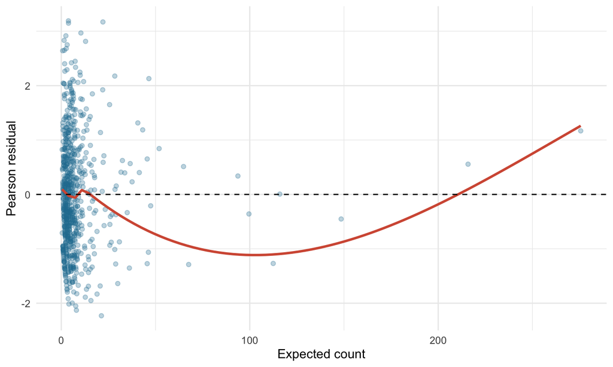

```r
poisson_diagnostics |>
  ggplot(aes(.fitted, .resid)) +
  geom_point(alpha = .3, color = "#237ba0") +
  geom_smooth(method = "loess", se = FALSE, color = "#d45a42") +
  geom_hline(yintercept = 0, linetype = "dashed") +
  labs(x = "Expected count", y = "Pearson residual")
```

```r
poisson_diagnostics |>
  select(tract_id, heat_visits, person_years, .fitted, .resid, .hat, .cooksd) |>
  slice_max(.cooksd, n = 5, with_ties = FALSE)
```

```
# A tibble: 5 × 7
  tract_id heat_visits person_years .fitted .resid   .hat .cooksd
  <chr>          <int>        <int>   <dbl>  <dbl>  <dbl>   <dbl>
1 T0476            295         3119   276.   1.17  0.466   0.202
2 T0468            224         3517   216.   0.556 0.600   0.105
3 T0231             40         3820    28.4  2.18  0.0732  0.0367
4 T0710             11         1555    21.3 -2.23  0.0625  0.0322
5 T0248             39         1316    46.2 -1.06  0.187   0.0291
```

We are checking whether the Poisson model adequately describes **the variation in visit counts and the frequency of zero visits**, after accounting for predictors and person-years. The **Pearson ratio** compares the remaining variation with what the model expects: values near 1 are reassuring, while values substantially above 1 suggest **overdispersion**, or more variation than the Poisson model allows. For the main outcome, the ratio is **1.06**, and the observed percentage of zeros (**6.0%**) is close to the predicted percentage (**6.4%**). These checks are reassuring, but do not establish that every aspect of the model is correct. We also inspect residual patterns and influential observations. The Cook’s distance table identifies records that could strongly affect the fitted model; these should be investigated for errors and unusual characteristics, not automatically deleted.

### A separate outcome with extra conditional variation

`heat_visits_extra` has the same specified conditional mean but was generated from a negative-binomial distribution. We do not alter the observed main outcome to make its diagnostics “pass.”

```r
poisson_extra <- glm(
  heat_visits_extra ~ heat5 * cooling_access + poverty10 +
    impervious_c10 + impervious_c10_sq + housing_profile + warning_program +
    offset(log(person_years)),
  family = poisson(link = "log"), data = gdat
)

extra_diagnostics <- augment(poisson_extra, data = gdat,
                             type.predict = "response", type.residuals = "pearson")

extra_diagnostics |>
  summarise(Pearson_ratio = sum(.resid^2) / df.residual(poisson_extra),
            observed_zero_fraction = mean(heat_visits_extra == 0),
            predicted_zero_fraction = mean(dpois(0, lambda = .fitted)))
```

```
# A tibble: 1 × 3
  Pearson_ratio observed_zero_fraction predicted_zero_fraction
          <dbl>                  <dbl>                   <dbl>
1          6.35                  0.167                  0.0681
```

The second outcome, `heat_visits_extra`, is a **separate teaching example** deliberately generated with greater variation—not a correction to the original data. Its Pearson ratio is **6.35**, indicating substantially more variation than the fitted Poisson model expects. It also contains more zeros than predicted: **16.7% observed versus 6.8% predicted**. This suggests that ordinary Poisson uncertainty estimates may be too small, producing confidence intervals that are too narrow. We should investigate model specification and consider an approach that accommodates extra variation, such as negative-binomial regression. Extra zeros alone do **not** prove that a special zero-inflated model is needed; a negative-binomial model may explain both the additional variation and the zeros.

## 8 · Two responses to overdispersion

### Quasi-Poisson: a different uncertainty calculation

```r
quasi_model <- glm(formula(poisson_extra), family = quasipoisson(link = "log"), data = gdat)

bind_rows(tidy(poisson_extra) |> mutate(model = "Poisson"),
          tidy(quasi_model) |> mutate(model = "Quasi-Poisson")) |>
  filter(term %in% c("heat5", "heat5:cooling_accessReliable")) |>
  select(model, term, estimate, std.error)
```

```
# A tibble: 4 × 4
  model         term                         estimate std.error
  <chr>         <chr>                           <dbl>     <dbl>
1 Poisson       heat5                           0.219    0.0111
2 Poisson       heat5:cooling_accessReliable   -0.152    0.0217
3 Quasi-Poisson heat5                           0.219    0.0280
4 Quasi-Poisson heat5:cooling_accessReliable   -0.152    0.0547
```

**Quasi-Poisson accounts for extra variation by changing the uncertainty estimates.** With the same predictors and data, its coefficients and predicted counts match ordinary Poisson, but its standard errors are larger here. For example, the heat coefficient stays at **0.219**, while its standard error increases from **0.011 to 0.028**. This produces wider confidence intervals, acknowledging that ordinary Poisson was too confident. These coefficients are on the **log-rate scale**, rather than the exponentiated IRR scale shown earlier. Quasi-Poisson does not fix missing confounders, incorrect relationships, or dependence between observations, and **ordinary AIC cannot be used to compare it with Poisson or negative-binomial models**.

### Negative binomial: model extra conditional variance

```r
nb_model <- MASS::glm.nb(formula(poisson_extra), data = gdat)

tidy(nb_model, conf.int = TRUE, exponentiate = TRUE) |>
  select(term, estimate, conf.low, conf.high)
```

```
# A tibble: 11 × 4
   term                         estimate conf.low conf.high
   <chr>                           <dbl>    <dbl>     <dbl>
 1 (Intercept)                   0.00269  0.00232   0.00312
 2 heat5                         1.32     1.21      1.44
 3 cooling_accessPartial         0.757    0.647     0.885
 4 cooling_accessReliable        0.570    0.473     0.687
 5 poverty10                     1.44     1.30      1.60
 6 impervious_c10                1.11     1.06      1.17
 7 impervious_c10_sq             1.09     1.07      1.11
 8 housing_profileVulnerable     1.36     1.18      1.56
 9 warning_programYes            0.726    0.632     0.834
10 heat5:cooling_accessPartial   0.911    0.826     1.00
11 heat5:cooling_accessReliable  0.805    0.718     0.904
```

```r
tibble(model = c("Poisson for extra outcome", "Negative binomial for extra outcome"),
       AIC = c(AIC(poisson_extra), AIC(nb_model)))
```

```
# A tibble: 2 × 2
  model                                 AIC
  <chr>                               <dbl>
1 Poisson for extra outcome           6419.
2 Negative binomial for extra outcome 3907.
```

```r
nb_expected <- predict(nb_model, type = "response")

tibble(theta = nb_model$theta,
       Pearson_ratio = sum(residuals(nb_model, type = "pearson")^2) / df.residual(nb_model),
       observed_zero_fraction = mean(gdat$heat_visits_extra == 0),
       predicted_zero_fraction = mean(dnbinom(0, mu = nb_expected, size = nb_model$theta)))
```

```
# A tibble: 1 × 4
  theta Pearson_ratio observed_zero_fraction predicted_zero_fraction
  <dbl>         <dbl>                  <dbl>                   <dbl>
1  1.54         0.972                  0.167                   0.160
```

**Negative-binomial regression explicitly allows more variation than Poisson**, and both its coefficients and uncertainty estimates can change. For this same outcome and the same observations, its much lower AIC—approximately **3,907 versus 6,419**—strongly favors it over ordinary Poisson. Its diagnostics are also reassuring: the Pearson ratio is approximately **0.97**, close to 1, and it predicts **16.0% zeros**, close to the observed **16.7%**. The estimated `theta` controls the extra variation; smaller values indicate greater overdispersion, while large values approach Poisson. Together, these results suggest that negative-binomial regression describes this outcome substantially better, although they do not prove that all model assumptions are satisfied or that the associations are causal.

## 9 · Geographic context and what remains to check

The GLM outcomes here were generated conditionally independently. That does not excuse us from assessing dependence in a real application. Plot Pearson residuals against the artificial coordinates and compare their pattern with the exposure pattern if useful.

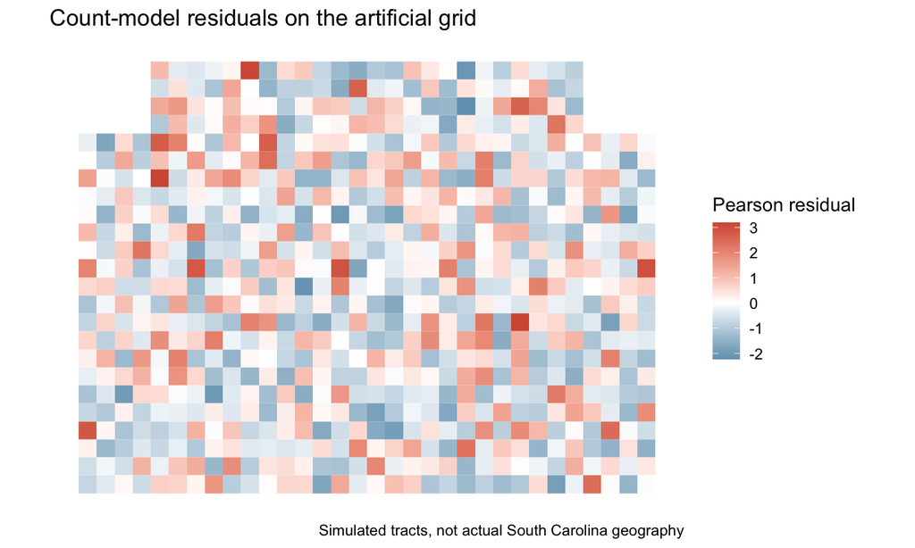

```r
poisson_diagnostics |>
  ggplot(aes(x, y, fill = .resid)) +
  geom_tile() + coord_equal() +
  scale_fill_gradient2(low = "#237ba0", mid = "white", high = "#d45a42", midpoint = 0) +
  labs(x = NULL, y = NULL, fill = "Pearson residual",
       title = "Count-model residuals on the artificial grid",
       caption = "Simulated tracts, not actual South Carolina geography") +
  theme(axis.text = element_blank(), panel.grid = element_blank())
```

This map checks whether the model’s **remaining prediction errors show a geographic pattern**. Each square represents a simulated tract. Red indicates more visits than predicted, blue indicates fewer visits than predicted, and white indicates an outcome close to the prediction. Large clusters of red or blue would suggest that the model consistently underpredicts or overpredicts in particular areas, potentially because of missing geographically patterned predictors or spatial dependence. Here, the colors appear fairly mixed, with no obvious large-scale clustering, which is reassuring.

However, **a map alone cannot establish that observations are spatially independent**; it is an initial visual check that can guide further spatial diagnostics. These simulated outcomes were generated independently after accounting for their predictors and person-years, so strong remaining spatial patterns are not expected. In real geographic data, we must investigate this rather than assume it. Allowing extra variation through negative-binomial regression does not automatically address spatial dependence, and this particular map displays residuals from the **main Poisson model**, not the negative-binomial model.

## Documentation and verification

- [broom tidy GLMs](https://broom.tidymodels.org/reference/tidy.glm.html) and [augment GLMs](https://broom.tidymodels.org/reference/augment.glm.html).
- [R GLM families and links](https://stat.ethz.ch/R-manual/R-devel/library/stats/html/family.html), [offsets](https://stat.ethz.ch/R-manual/R-devel/library/stats/html/offset.html), and [model formula interaction operators](https://stat.ethz.ch/R-manual/R-devel/library/stats/html/formula.html).
- [MASS negative-binomial regression](https://stat.ethz.ch/R-manual/R-devel/library/MASS/html/glm.nb.html).

The examples are original simulations, not evidence about South Carolina. Core estimates and diagnostic patterns were checked with independent Python likelihood and linear-model calculations. Native R/Quarto execution was unavailable during creation. The instructor should render once in a prepared Posit Cloud project before distributing it. No external data file is required.